# Analysis of the Beverage Production Factors that Impact Product pH at ABC Beverage Company

Zach Herold, Anthony Pagan, Betsy Rosalen

5/10/2020

# Project Description

## Data Analysis of the impact of ABC Beverage Manufacturing Process on pH

This report contains the findings of the data analysis undertaken by the data science team, lead by Zach Herold, Anthony Pagan, and Betsy Rosalen at ABC Beverage Company in order to better understand the impact of manufacturing processes on the pH level in our products and to comply with new federal regulations. The report has the following aims:

- to further senior management’s general understanding of the ABC Beverage manufacturing process that impact pH;
- to internally prepare for inquiries and procedures pursuant to recent changes in the regulatory environment;
- specifically, to explicate the effect manufacturing processes have on beverage pH and a present a generalized model for predicting pH levels from input and process calibrations.

This report details the results and conclusions reached from the analysis and excludes technical details. For technical details about steps taken in our analysis, including the assumptions made, the methodology used, the models tested, and the model selection process please see the technical report, “Analysis of the Beverage Production Factors that Impact Product pH at ABC Beverage Company - Technical Report”.

# Data Description

## Variable Summary Statistics and Distributions

### Distributions

Our predictors have a wide range of distributions with some normal, some skewed, some multi-modal, and some with high zero inflation. Our target, `PH`, has a mostly normal distribution.

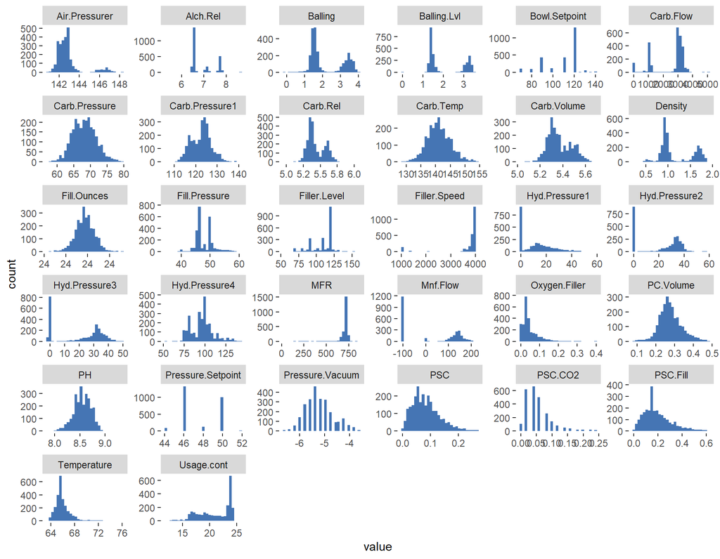

### Missing Values

There was some missing data in our predictors most noticeably in `MFR`, which had 8.25% missing values as can be seen in the plot below. There didn’t immediately seem to be any pattern in the missingness however, after our analysis we discovered some patterns which will be detailed in the section on “Understanding `Mnf.Flow`”. Missing values were handled automatically in our final model algorithm, so they were not imputed or removed from the dataset.

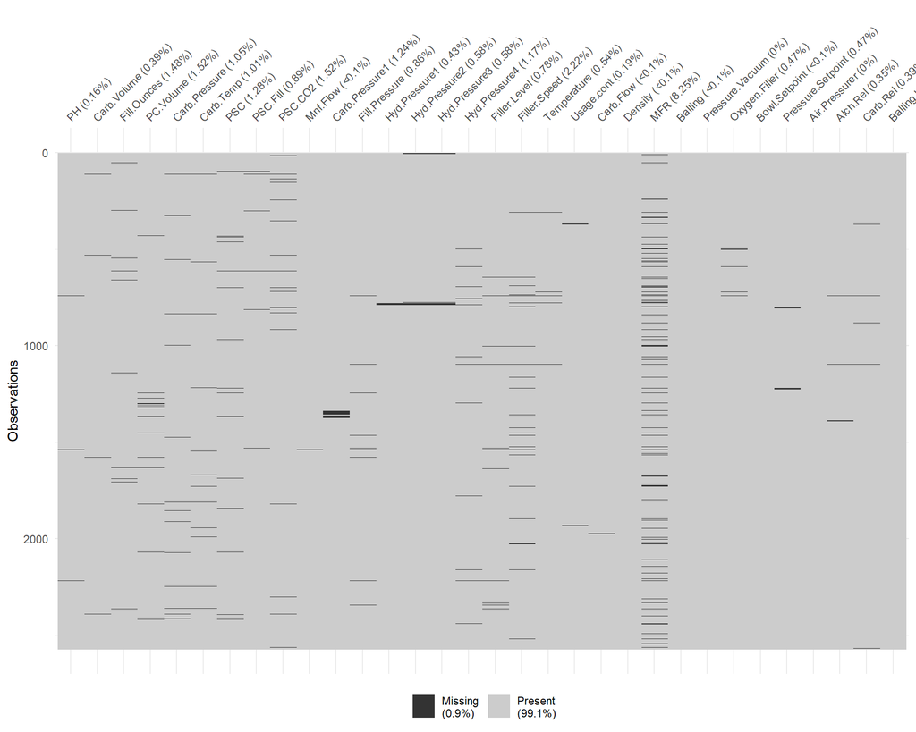

## Relationships Between Variables

### Correlations

The correlation plot on the next page shows some strong correlations between predictors. Correlated predictors share the same predictive value and so can often be used interchangeably in a model. As a result, one from each pair is often removed from the model formula in order to increase model stability.

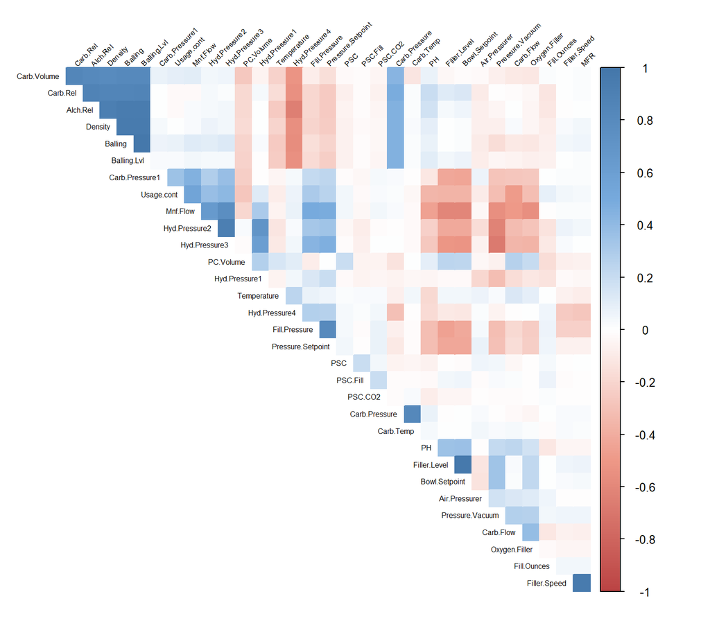

What we found is that there were exactly 5 variables that were most frequently associated with highly correlated pairs. Removing these variables, `Alch.Rel`, `Balling`, `Balling.Lvl`, `Carb.Rel`, and `Density` as well as `Filler.Speed`, `Hyd.Pressure2` and `Filler.Level` would eliminate all 13 highly correlated pairs in or data, however, after tuning models we discovered that we got better performance from a model type that is not as influenced by correlated predictors, called Random Forest, and by using the full set of predictors. So no variables were removed from our final model formula.

# Models

We trained and tuned a full range of model types including: Linear Regression, Ridge Regression, Lasso, Random Forest, Tree Bag, CTree, Classification and Regression Tree (CART), Multivariate Adaptive Regression Splines (MARS), K-Nearest Neighbors (KNN) and Support Vector Machine (SVM).

We chose a model that minimized error (measured as root mean squared error or RMSE) and maximized predictive value (measured as $R^2$ R-squared). The Random Forest model achieved this. The Random Forest regression model is a machine learning technique that randomly leaves out candidate features from each decision tree split, run on multiple iterations. In doing so, it “decorrelates” the trees, such that the averaging process can reduce the variance of the resulting models.

## Sample Decision Tree

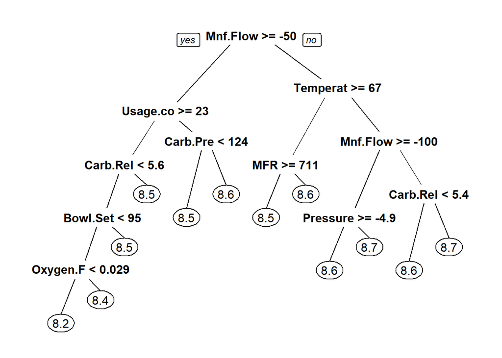

It’s notable, however, that the tree only predicts pH levels in the middle of it’s range. `PH` in our dataset ranges from 7.88 to 9.36 however our tree only predicts from 8.2 to 8.7.

## Comparison of Random Forest to Standard OLS Linear Regression

When we compare the Adjusted-$R^2$ ‘goodness of fit’ measure of a conventional linear regression model that uses the ten most important variables from our random forest model as predictors to one which uses all the variables as inputs, we note a very minor loss in goodness-of-fit. By removing two more statistically insignificant variables, `Pressure.Vacuum` and `Hyd.Pressure1`, we arrive at the model below:

```
##
## Call:
## lm(formula = .outcome ~ ., data = dat)
##
## Residuals:
##     Min      1Q  Median      3Q     Max
## -0.5965 -0.0789  0.0132  0.0942  0.4038
##
## Coefficients:
##                     Estimate Std. Error t value             Pr(>|t|)
## (Intercept)        9.9125788  0.3363073   29.47 < 0.0000000000000002 ***
## Mnf.Flow          -0.0007354  0.0000593  -12.39 < 0.0000000000000002 ***
## Usage.cont        -0.0088554  0.0014988   -5.91  0.00000000428219377 ***
## Carb.Rel           0.1582415  0.0308415    5.13  0.00000032670276525 ***
## Bowl.Setpoint      0.0011341  0.0003023    3.75              0.00018 ***
## Temperature       -0.0289059  0.0035593   -8.12  0.00000000000000096 ***
## Oxygen.Filler     -0.5367611  0.1120182   -4.79  0.00000181946486437 ***
## Pressure.Setpoint -0.0056361  0.0021453   -2.63              0.00870 **
## Hyd.Pressure3      0.0025705  0.0003675    7.00  0.00000000000398964 ***
## ---
## Signif. codes:  0 '***' 0.001 '**' 0.01 '*' 0.05 '.' 0.1 ' ' 1
##
## Residual standard error: 0.138 on 1481 degrees of freedom
## Multiple R-squared:  0.331,  Adjusted R-squared:  0.328
## F-statistic: 91.7 on 8 and 1481 DF,  p-value: <0.0000000000000002
```

One interesting finding from this experiment was that we were able to determine that the impact of `Mnf.Flow`, `Usage.conf`, `Temperature`, `Oxygen.Filler`, and `Pressure.Setpoint` are negative due to the negative coefficients (in the “Estimate” column above) and the impact of `Carb.Rel`, `Bowl.Setpoint`, and `Hyd.Pressure3` are positive due to positive coefficients. So there is a balancing act between these most influential variables with some pulling in one direction on the pH and some in the other. Thus a change in one may necessitate a change in the others.

## Understanding `Mnf.Flow`

Since we found that several models, considered `Mnf.Flow` to be the most critical input, we visualized the distribution of the `Mnf.Flow` data in a histogram and in a scatterplot against `PH`:

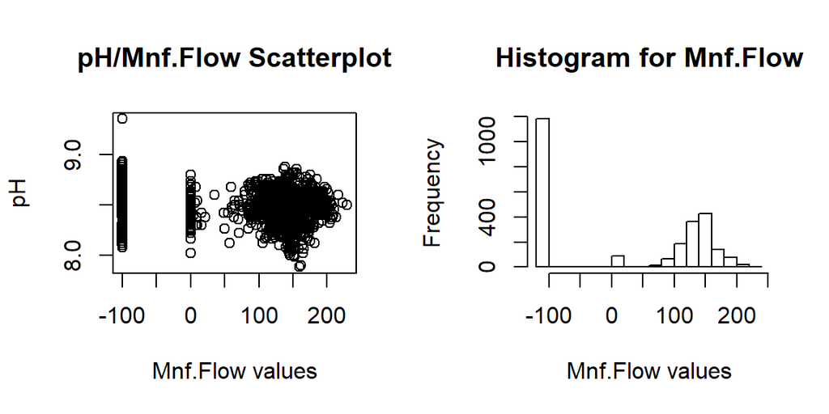

We made the following observations about `Mnf.Flow`:

1. Of the 2567 observations in our training set, 1183 (46%) have a value of -100 or less which can be clearly seen in the histogram.
2. We note that the mean value of all non-negative `Mnf.Flow` data is 140.
3. A disproportional number of our missing values come from observations in which the `Mnf.Flow` is between 0 and 1. Although only 3% of all observations have this range of `Mnf.Flow`, 18% of the observations with missing values come from this subset.

The negative influence of `Mnf.Flow` is subtle but apparent in the violinplot below, separated by buckets of Mnf.FLow in the following ranges {1: [-1000, -1), 2: [-1, 1), 3: [1, 140), 4: [140, 1000]}

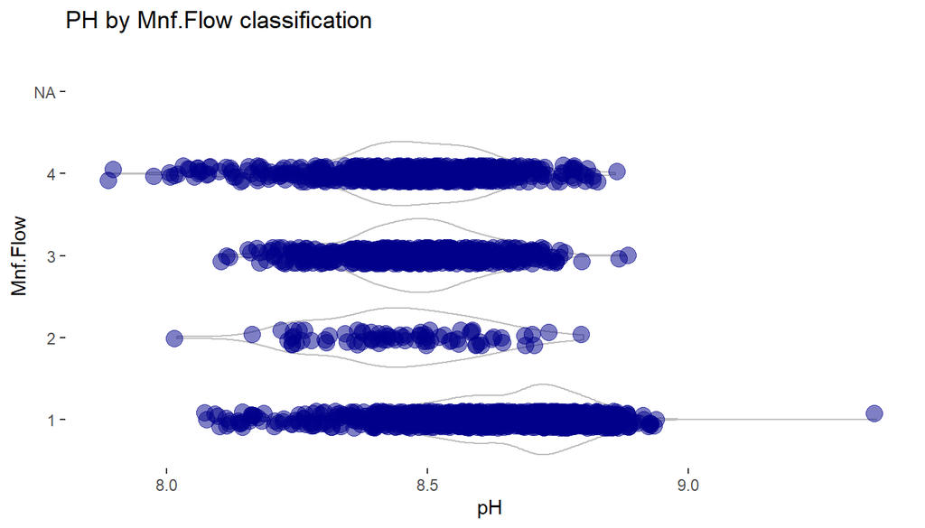

## Modeling by Brand

In another experiment we divided the dataset into subsets according to `Brand.Code` in order to assess what production processes are most relevant for each brand type. We imputed missing values by replacing them with the trimmed mean and then applied a random forest model to each of the four subsets. Our aim was to determine if the variables found to be most important for the whole dataset carry through to the subsets.

The mean pH for our dataset is 8.55, however, from the violin plot below, we observe that the distribution of pH values for Brand D tends to be above mean, while that of Brand C is markedly below mean. We further investigated what factors determine the acidic signature of Brand C, with the conclusion that lower balling method levels (which promote solution alkalinity) may at least partially contribute.

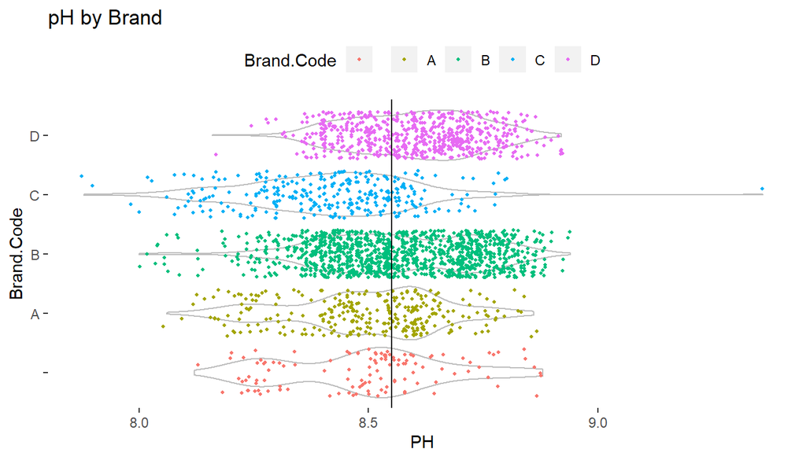

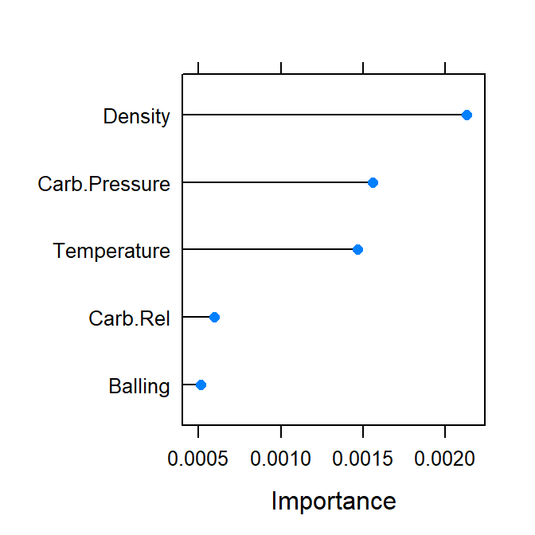

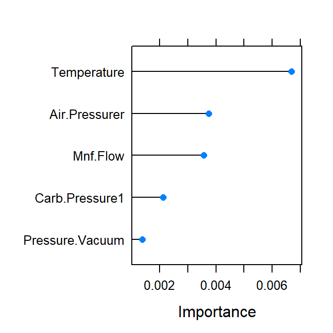

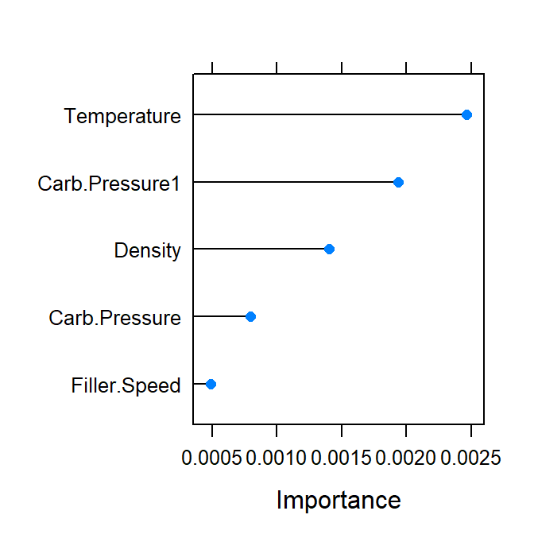

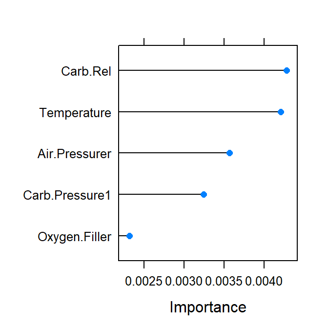